# Machine Learning in Python - Project 1

Due Friday, March 6th by 5 pm.

## 1. Setup

### 1.1 Libraries

```python
# uncomment and run to install module for the correlation plot
!pip install biokit
```

```python
# Add any additional libraries or submodules below

# Display plots inline
%matplotlib inline

# Data libraries
import pandas as pd
import numpy as np

# Plotting libraries
import matplotlib.pyplot as plt
import seaborn as sns

# Plotting defaults
plt.rcParams['figure.figsize'] = (8,5)
plt.rcParams['figure.dpi'] = 80

# sklearn modules
import sklearn
from sklearn.linear_model import LinearRegression, Ridge, Lasso
from sklearn.metrics import mean_squared_error
from sklearn.pipeline import make_pipeline
from sklearn.model_selection import GridSearchCV, KFold
from sklearn.preprocessing import StandardScaler

from biokit.viz import corrplot

import warnings
warnings.filterwarnings('ignore')
```

### 1.2 Data

```python
sales = pd.read_csv("sales.csv")
sales_test = pd.read_csv("sales_test.csv")
```

## 2. Exploratory Data Analysis and Preprocessing

```python
sales
```

|  | sale_price | year_sold | year_built | lot_area | basement_area | living_area | full_bath | half_bath | bedroom | garage_cars | garage_area | ac | zoning | neighborhood | quality | condition |
| --- | --- | --- | --- | --- | --- | --- | --- | --- | --- | --- | --- | --- | --- | --- | --- | --- |
| 0 | 244000 | 2010 | 1968 | 11160 | 2110 | 2110 | 2 | 1 | 3 | 2 | 522 | Y | Residential_Low_Density | nb_07 | good | average |
| 1 | 189900 | 2010 | 1997 | 13830 | 928 | 1629 | 2 | 1 | 3 | 2 | 482 | Y | Residential_Low_Density | nb_22 | average | average |
| 2 | 191500 | 2010 | 1992 | 5005 | 1280 | 1280 | 2 | 0 | 2 | 2 | 506 | Y | Residential_Low_Density | nb_10 | good | average |
| 3 | 236500 | 2010 | 1995 | 5389 | 1595 | 1616 | 2 | 0 | 2 | 2 | 608 | Y | Residential_Low_Density | nb_10 | good | average |
| 4 | 189000 | 2010 | 1999 | 7500 | 994 | 1804 | 2 | 1 | 3 | 2 | 442 | Y | Residential_Low_Density | nb_22 | good | average |
| ... | ... | ... | ... | ... | ... | ... | ... | ... | ... | ... | ... | ... | ... | ... | ... | ... |
| 1579 | 79500 | 2006 | 1970 | 1526 | 546 | 1092 | 1 | 1 | 3 | 0 | 0 | Y | Residential_Medium_Density | nb_02 | average | average |
| 1580 | 160000 | 2006 | 1977 | 17400 | 1126 | 1126 | 2 | 0 | 3 | 2 | 484 | Y | Residential_Low_Density | nb_20 | average | average |
| 1581 | 142500 | 2006 | 1984 | 7937 | 1003 | 1003 | 1 | 0 | 3 | 2 | 588 | Y | Residential_Low_Density | nb_20 | average | average |
| 1582 | 132000 | 2006 | 1992 | 10441 | 912 | 970 | 1 | 0 | 3 | 0 | 0 | Y | Residential_Low_Density | nb_20 | average | average |
| 1583 | 170000 | 2006 | 1974 | 10010 | 1389 | 1389 | 1 | 0 | 2 | 2 | 418 | Y | Residential_Low_Density | nb_20 | average | average |

1584 rows × 16 columns

We are given data on house sales in years 2006-2010 in a U.S city, divided into training data `sales` and testing data `sales_test`, which contain 1584 and 350 samples, respectively. The data originally has 16 columns. We are going to model the data in the first column - `sale_price` (of a house) - using the other 15 features.

Using some plots and tools, we will now analyse the the features based on their values and the influence they have on the on the sale price, observe some relationships in between them and pre-process the data to get a better model.

*Numerical data*

We can gain more insight looking at a correlation plot for the non-categorical data using `biokit` (documentation [here](https://nbviewer.jupyter.org/github/biokit/biokit/blob/master/notebooks/viz/corrplot.ipynb)), which displays the relationships nicely - blue/red is positive/negative correlation and the size and colour of the square is proportional to the size of the correlation.

- The most remarkable correlations are between `garage_cars` and `garage_area`, and they also display similar correlation with other properties.
- `year_sold` does not show correlation to any of the data. As one may have expected, the age has a negative correlation with the price (for regular houses, an old castle might be expensive though). Another interesting aspect we observe is that age is negatively correlated with garage area and number of car lots, also with basement area and number of bathrooms. The feature `year_built` has the opposite correlation to `sale_age`.
- `living_area` is correlated strongly with `sale_price` which is understandable as well. Another features correlated with higher price are the number of full baths and garage area.
- What might have not been expected is that `lot_area` neither `bedrooms` are correlated with the price much (0.29 and 0.19, respectively). We will, however, keep this data.

*Non-numerical categorical data*

The last 5 features in our data are non-numerical and categorical. Since we would like our data to be numerical, we will transform the categorical properties into numbers via One Hot Encoding using `get_dummies` and make separate columns with values 1 or 0 for specific values in them. To decide whether to include all of the columns we were given, we will make a few plots.

We start with the column `neighborhood`, and we would like to know whether a neighbourhood has an impact on the price - see the next boxplot. We notice, that some neighbourhoods, like `nb_03` and `nb_19`, are more pricy then the others, especially `nb_02`. Therefore we decide to keep this data and unpack it with `get_dummies` later. However, if we unpacked all of the neighborhoods, we would get 24 columns/properties in total, which is quite a lot (especially in proportion to how much data we have in `sales_test` - we want to avoid under/overfitting). Instead, we will sort the neighborhoods by their mean price and make 3 groups: cheap, average and expensive neighborhoods (see the second boxplot).

In order to conclude whether and how air conditioning, `ac`, is important, we will make a swarmplot and use `quality` for the hue. We see that more houses had attribute Yes than No, and that very expensive houses (>270000 USD) all had `ac`. Average quality houses do not necessarily have air conditioning. Those houses of good and excellent quality, which are also among the more expensive ones, almost all have ac. Seeing this relationships we decide to include this data to make the model.

More on `quality` in the next two plots: The boxplot shows us that quality of the house decreases with age. There are also many outliers for good and average quality and older houses. In the swarmplot we can see direct relationship - sale price increasing in proportion to quality.

In a boxplot for `zoning`, we observe that the less dense areas are more expensive, so the zone of the house matters and we will not drop this data. However, only a small proportion of houses is in Medium and High density zones. Also, the zones' medians are quite close to each other. Overall, there is no strong trend present here.

The next violinplot and a set of swarmplots shows us the relationship between `sales_price`, `quality` and `condition`. Although from the violinplot it might seem that the rating of quality and condition of the house might be similar (because of similarly distributed data in each of the categories, compared to the previous swarmplot for `quality`), which would suggest we do not need both of these features, the swarmplots show us that it is not true. Quality=excellent is observed far more frequently with condition=average than with conition=excellent, although with higher price, and we get both excellent and poor condition with average quality. This means quality is not directly in relationship with condition and both columns are relevant.

```python
# completeness of the data
sales.isnull().values.any()
```

```
False
```

```python
# skewness
features = sales.dtypes[sales.dtypes!='object'].index
sales[features].skew().sort_values()
```

```
year_built       -0.557369
garage_cars      -0.050364
year_sold         0.073549
bedroom           0.211899
garage_area       0.222085
full_bath         0.348926
basement_area     0.529733
half_bath         0.728396
living_area       1.009878
sale_price        1.954549
lot_area         11.794075
dtype: float64
```

```python
# creating new columns
sales['log_sale_price'] = np.log(sales['sale_price'])
sales['log_lot_area'] = np.log(sales['lot_area'])
sales['sale_age'] = sales['year_sold'] - sales['year_built']

sales_test['log_sale_price'] = np.log(sales_test['sale_price'])
sales_test['log_lot_area'] = np.log(sales_test['lot_area'])
sales_test['sale_age'] = sales_test['year_sold'] - sales_test['year_built']

sales_prices = sales['sale_price']
```

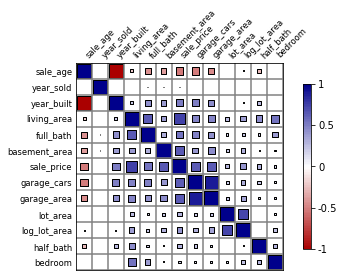

```python
# correlation plot
sales_c = sales.drop('log_sale_price', axis=1).corr() # unnecessary to include log of the sale price in the correlation plot
corrplot.Corrplot(sales_c).plot(colorbar=True, method='square', rotation=45)
```

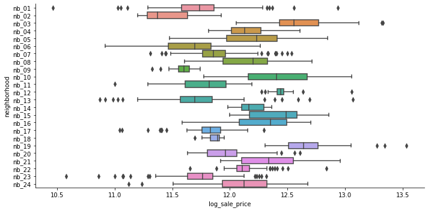

```python
# log price vs neighbourhoods before grouping
neigh_names = list(sales['neighborhood'].sort_values().unique())
sns.catplot(x = "log_sale_price",y = "neighborhood",kind = "box",data = sales,order=neigh_names,aspect = 2)
```

```python
# grouping neighbourhoods by mean price
r = pd.DataFrame(sales.groupby('neighborhood')['sale_price'].mean().sort_values())
neighb_cheap = r.index.values[0:8]
neighb_med = r.index.values[8:16]
neighb_exp = r.index.values[16:24]

sales['neighborhood'] = sales['neighborhood'].replace(neighb_cheap,'cheap')
sales['neighborhood'] = sales['neighborhood'].replace(neighb_med,'medium')
sales['neighborhood'] = sales['neighborhood'].replace(neighb_exp,'expensive')

sales_test['neighborhood'] = sales_test['neighborhood'].replace(neighb_cheap,'cheap')
sales_test['neighborhood'] = sales_test['neighborhood'].replace(neighb_med,'medium')
sales_test['neighborhood'] = sales_test['neighborhood'].replace(neighb_exp,'expensive')
```

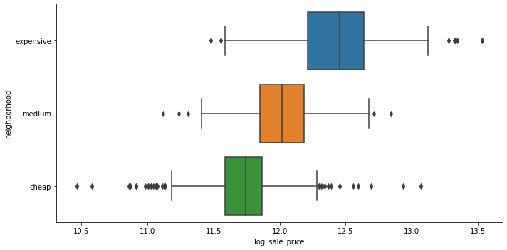

```python
# log price vs neighbourhoods after grouping
sns.catplot(x = "log_sale_price",y = "neighborhood",kind = "box",order=['expensive','medium','cheap'],data = sales,aspect = 2)
```

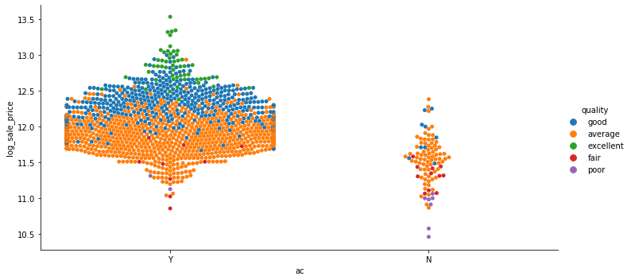

```python
# log price vs air conditioning vs quality
sns.catplot(x="ac", y="log_sale_price", hue='quality',kind='swarm',data=sales,aspect=2)
```

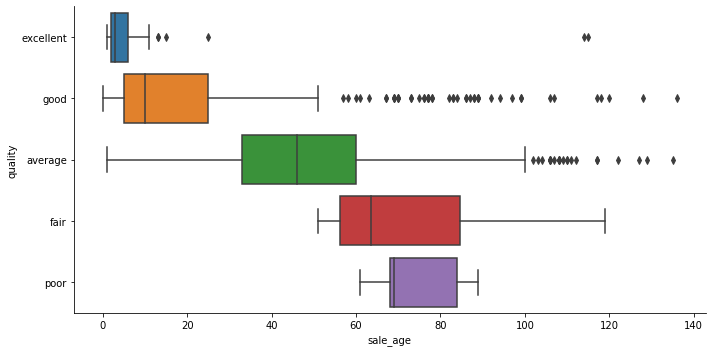

```python
# quality vs age
sns.catplot(x='sale_age',y='quality',kind='box',order=['excellent','good','average','fair','poor'],data=sales,aspect=2)
```

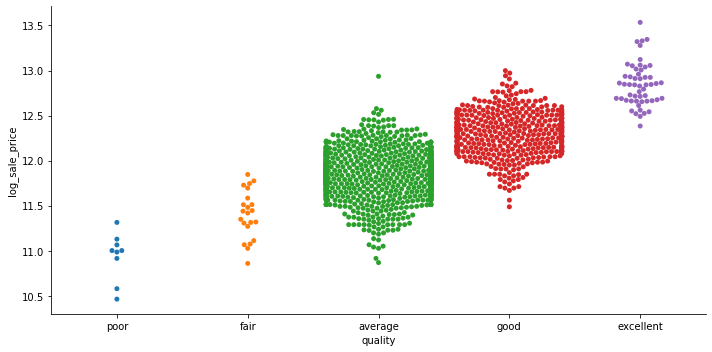

```python
# log price vs quality
sns.catplot(y='log_sale_price',x='quality',kind='swarm',order=['poor','fair','average','good','excellent'],data=sales,aspect=2)
```

```
Residential_Low_Density       1309
Residential_Medium_Density     266
Residential_High_Density         9
Name: zoning, dtype: int64
```

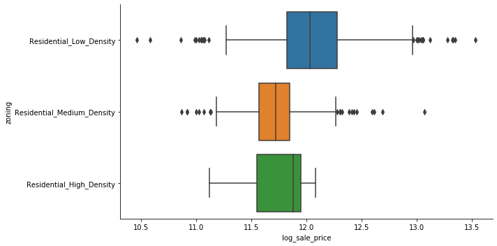

```python
# price vs zoning
sns.catplot(x="log_sale_price", y="zoning", kind="box",data=sales,aspect=2)
sales['zoning'].value_counts()
```

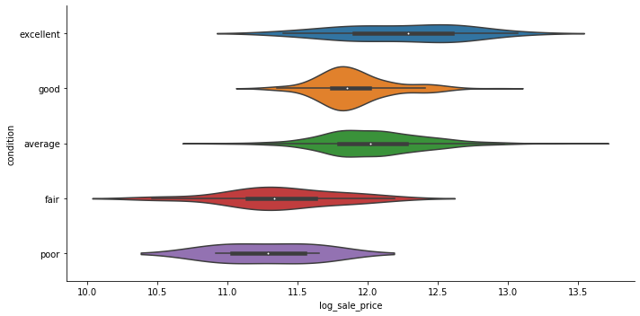

```python
# log price vc condition
sns.catplot(x="log_sale_price", y="condition", kind="violin",order=['excellent','good','average','fair','poor'],data=sales,aspect=2)
```

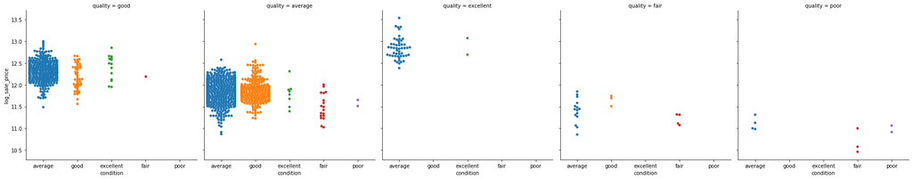

```python
# log price vs condition sorted by quality
sns.catplot(x="condition", y="log_sale_price", col="quality",kind="swarm",data=sales)
```

## 3. Model Fitting and Tuning

Since we created a new column `sale_age`, after considering the correlations we will drop both `year_sold`, because it was decorrelated with other features, and `year_built`, because `sale_age` is capturing the opposite behaviour to `year_built` (it has the opposite correlation, because of the way the column was constructed).

Next, because of similar correlations of `garage_cars` and `garage_area`, we will therefore drop `garage_cars`, since the the area is enough for us and it might capture the price change better. Number of garage cars is categorical in nature, and with the same number of cars, garage area and price can vary (e.g. additional space in the garage for other stuff).

Because of not seeing a strong trend between zoning and the price, we will not take `zoning` into account.

Finally, since we transformed `sale_price` and `lot_area` by taking the logarithm, we will keep the new columns only and get rid of the old, skewed ones.

At the end we have 24 columns.

```python
yt = sales_test['sale_price']
sales = sales.drop(['year_sold','year_built','garage_cars','sale_price','lot_area','zoning'], axis=1)
sales_test = sales_test.drop(['year_sold','year_built','garage_cars','sale_price','lot_area','zoning'], axis=1)

sales = pd.get_dummies(sales,drop_first=False)
sales_test = pd.get_dummies(sales_test,drop_first=False)
sales = sales.sample(frac=1) # Shuffle rows

print(sales.shape)
```

```
(1584, 24)
```

```python
# helper functions taken from workshop 5
def get_coefs(m):
    """Returns the model coefficients from a Scikit-learn model object as an array,
    includes the intercept if available.
    """

    if m.intercept_ is None:
        return m.coef_

    return np.concatenate([[m.intercept_], m.coef_])

def model_fit(m, X, y, plot = False):
    """Returns the root mean squared error of a fitted model based on provided X and y values.

    Args:
        m: sklearn model object
        X: model matrix to use for prediction
        y: outcome vector to use to calculating rmse and residuals
        plot: boolean value, should fit plots be shown
    """

    y_hat = np.exp(m.predict(X))
    rmse = np.sqrt(mean_squared_error(y, y_hat))


    res = pd.DataFrame(
        data = {'y': y, 'y_hat': y_hat, 'resid': y - y_hat}
    )

    if plot:
        plt.figure(figsize=(12, 6))

        plt.subplot(121)
        sns.lineplot(x='x', y='y', color="grey", data =  pd.DataFrame(data={'x': [min(y),max(y)], 'y': [min(y),max(y)]}))
        sns.scatterplot(x='y', y='y_hat', data=res).set_title("Fit plot")

        plt.subplot(122)
        sns.scatterplot(x='y', y='resid', data=res).set_title("Residual plot")

        plt.subplots_adjust(left=0.0)

        plt.suptitle("Model rmse = " + str(round(rmse, 4)), fontsize=16)
        plt.show()

    return rmse
```

**RIDGE REGRESSION**

After considering linear, lasso, and piecewise linear regression, and after comparing their RMSEs and residual plots, we settled for Ridge regression. Although linear regression gave us a slightly smaller RMSE, we chose Ridge because of its benefits (see the next section). The other two models had larger RMSEs. The residual plots are 'conic' for all of the methods - the models fit better the cheaper houses, than the more expensive ones (they are underpredicted). For comparison of the RMSEs we used data in `sales_test`.

To choose the right value of the penalization parameter `alpha` involved in Ridge Regression's Residual sum of squares, we perform Grid Search Cross-Validation using K-folds. First we tried to use 5 folds, but after running the code a couple of times, the best value of `alpha` varied with a big variance. We therefore increased the number of folds to 10 (we can do this, since our training data is large), and although the value still jumped, the variance decreased (the table demonstrates the situation).

| $\alpha$ 5 folds | RMSE 5 folds | $\alpha$ 10 folds | RMSE 10 folds |
| --- | --- | --- | --- |
| 5.8 | 19 572 | 5.1 | 19 570 |
| 4.2 | 19 568 | 5.4 | 19 571 |
| 3.2 | 19 565 | 4.7 | 19 569 |
| 1.7 | 19 562 | 6.8 | 19 575 |

Overall, the value of `alpha` is around 5, and the RMSE is approx. 19 570 $.

```python
# creating the data frames we will model with
X = sales.drop('log_sale_price', axis=1)
Xt = sales_test.drop('log_sale_price',axis=1)
y = sales['log_sale_price']
# and we have assigned yt at the beginning of this section, yt=sale_price of the test data
```

```python
# scaling the data
#X_comp = pd.concat([X,Xt])
S = StandardScaler().fit(X)
X_scaled = S.transform(X)
Xt_scaled = S.transform(Xt)
```

```python
# cross validation grid search, k=5
alphas = np.linspace(0, 15, num=151)
gs = GridSearchCV(
    Ridge(),
    param_grid={'alpha': alphas},
    cv=KFold(10, True, random_state=1234),
    scoring="neg_mean_squared_error"
).fit(X_scaled, y)

final_model = gs.best_estimator_
print("best alpha:", gs.best_params_['alpha'])
```

```
best alpha: 5.7
```

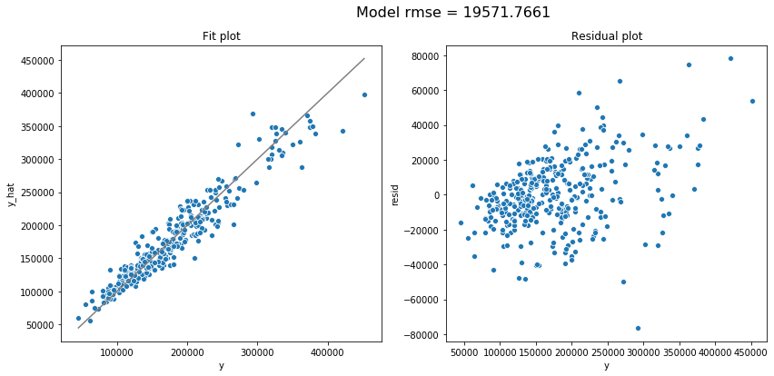

```
19571.76607371699
```

```python
model_fit(final_model, Xt_scaled, yt,plot=True)
```

To find out more about the chosen value for `alpha`, we can take a look at the performance of the folds. We will extract `mean_test_score` and the `split#_test_score`. On the plot we see that the curve is quite flat around its minimum, which causes mild instability in the values of `alpha`. However, this model provides us the mentioned benefits and the RMSE is quite stable.

```python
cv_res = pd.DataFrame(
    data = gs.cv_results_
).filter(
    # Extract the split#_test_score, mean_test_score, and std_test_score columns
    regex = '(split[0-9]+|mean)_test_score'
).assign(
    # Add the alphas as a column
    alpha = alphas
)

cv_res.update(
    # Convert negative rmses to positive
    -1 * cv_res.filter(regex = '_test_score')
)
```

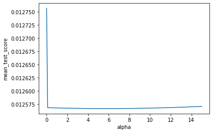

```python
sns.lineplot(x='alpha', y='mean_test_score', data=cv_res)
plt.show()
```

## 4. Discussion

The model we chose to predict house prices is Ridge regression. Ridge regression is a regularization technique, that shrinks the estimated weights of the features. It was achieved by adding a penalty function $\alpha \sum^D_{d=1} w^2_d$ to Linear regression's cost function (RSS - Residual Sum of Squares), therefore it penalizes large weight values (weight as an importance of the feature to the predicted sale house). In total we have:

$RSS_{ridge} = \sum^N_{n=1} (y_n - w^Tx)n)^2 + \alpha \sum^D_{d=1} w^2_d $

This penalization helps our model avoid overfitting, since it optimizes for prediction, and may work better on the unseen data than linear regression, especially in a model complex as this one (we have many features).

In the previous section we found out that the best value for alpha is $\sim 5$ and the RMSE is $\sim$ 19 570 USD. We achieved this by first looking at the features of the houses and their interactions. We decided, that the number of cars that fit into a garage and the zoning would not be that important (garage cars because garage area has similar relationship to other features, zoning because there was not a strong trend visible with lower zoning resulting in higher price, the boxplot showed us that the ranges of the zones overlayed and their medians were close). Next, we divided the neighbourhoods into 3 groups of 8 based on their mean price:

- cheap: 1, 2, 9, 6, 11, 13, 17, 23
- medium: 4, 7, 8, 14, 18, 20, 22, 24
- expensive: 3, 5, 10, 12, 15, 16, 19, 21

Also, we got more information about the house judging by its *age* at the year it was sold rather than the year it was built or sold. Hence we did not take the years into consideration and kept the age only.

The last important change we made was to take the log of price and the lot area, which made our modelling easier.

## 5. Model Validation

The RMSE we got with Ridge regression is around 19 570 USD. Is this too much? It depends on the house itself. In the test data, the cheapest house costs 45 000 USD. In this case, the RMSE is almost half of the price of the house. For the expensive houses, however, 20k is not that much of a difference.

A drawback of this model can be in the training data being old - the moct recent year of a house being sold is 2010 - 10 years ago. For this or next year, a more recent data would be necessary to get a better model.

```python
19570/np.mean(sales_prices)*100
```

```
11.208457996830763
```

```python
sales_holdout = pd.read_csv("sales_holdout.csv")

sales_holdout['log_sale_price'] = np.log(sales_holdout['sale_price'])
sales_holdout['log_lot_area'] = np.log(sales_holdout['lot_area'])
sales_holdout['sale_age'] = sales_holdout['year_sold'] - sales_holdout['year_built']

sales_holdout['neighborhood'] = sales_holdout['neighborhood'].replace(neighb_cheap,'cheap')
sales_holdout['neighborhood'] = sales_holdout['neighborhood'].replace(neighb_med,'medium')
sales_holdout['neighborhood'] = sales_holdout['neighborhood'].replace(neighb_exp,'expensive')

y_holdout = sales_holdout.sale_price

sales_holdout = sales_holdout.drop(['year_sold','year_built','garage_cars','sale_price','lot_area','zoning'], axis=1)
sales_holdout = pd.get_dummies(sales_holdout,drop_first=False)

X_holdout = sales_holdout.drop('log_sale_price', axis=1)

X_holdout_scaled = S.transform(X_holdout)
```

```python
# Calculate the root mean squared error for your model

y_hat = np.exp(final_model.predict(X_holdout_scaled))
np.sqrt(mean_squared_error(y_holdout, y_hat))
```

[output not shown]